# Air Quality Data Exploration

Brian High

Saturday, May 16, 2015

## Setup

Load the required packages.

```r
# Load one or more packages into memory, installing as needed.
load.pkgs <- function(pkgs, repos = "http://cran.r-project.org") {
    result <- sapply(pkgs, function(pkg) {
        if (!suppressWarnings(require(pkg, character.only = TRUE))) {
            install.packages(pkg, quiet = TRUE, repos = repos)
            library(pkg, character.only = TRUE)}})
}

load.pkgs(c("dplyr", "reshape2", "ggplot2"))
```

## Load the dataset

Let’s explore the [New York Air Quality Measurements](http://stat.ethz.ch/R-manual/R-patched/library/datasets/html/airquality.html) from R’s `dataset` package. We’ll start by loading the dataset and examining the structure.

```r
library(datasets)
data(airquality)

str(airquality)
```

```
## 'data.frame':    153 obs. of  6 variables:
##  $ Ozone  : int  41 36 12 18 NA 28 23 19 8 NA ...
##  $ Solar.R: int  190 118 149 313 NA NA 299 99 19 194 ...
##  $ Wind   : num  7.4 8 12.6 11.5 14.3 14.9 8.6 13.8 20.1 8.6 ...
##  $ Temp   : int  67 72 74 62 56 66 65 59 61 69 ...
##  $ Month  : int  5 5 5 5 5 5 5 5 5 5 ...
##  $ Day    : int  1 2 3 4 5 6 7 8 9 10 ...
```

## View some rows

It is always a good idea to take a look at a few rows of data to get oriented.

```r
head(airquality)
```

```
##   Ozone Solar.R Wind Temp Month Day
## 1    41     190  7.4   67     5   1
## 2    36     118  8.0   72     5   2
## 3    12     149 12.6   74     5   3
## 4    18     313 11.5   62     5   4
## 5    NA      NA 14.3   56     5   5
## 6    28      NA 14.9   66     5   6
```

```r
tail(airquality)
```

```
##     Ozone Solar.R Wind Temp Month Day
## 148    14      20 16.6   63     9  25
## 149    30     193  6.9   70     9  26
## 150    NA     145 13.2   77     9  27
## 151    14     191 14.3   75     9  28
## 152    18     131  8.0   76     9  29
## 153    20     223 11.5   68     9  30
```

## Basic statistical summary

With `summary`, we get a quick view of `NA`s, max, min, median, mean and first and third quartiles.

```r
summary(airquality)
```

```
##      Ozone           Solar.R           Wind             Temp
##  Min.   :  1.00   Min.   :  7.0   Min.   : 1.700   Min.   :56.00
##  1st Qu.: 18.00   1st Qu.:115.8   1st Qu.: 7.400   1st Qu.:72.00
##  Median : 31.50   Median :205.0   Median : 9.700   Median :79.00
##  Mean   : 42.13   Mean   :185.9   Mean   : 9.958   Mean   :77.88
##  3rd Qu.: 63.25   3rd Qu.:258.8   3rd Qu.:11.500   3rd Qu.:85.00
##  Max.   :168.00   Max.   :334.0   Max.   :20.700   Max.   :97.00
##  NA's   :37       NA's   :7
##      Month            Day
##  Min.   :5.000   Min.   : 1.0
##  1st Qu.:6.000   1st Qu.: 8.0
##  Median :7.000   Median :16.0
##  Mean   :6.993   Mean   :15.8
##  3rd Qu.:8.000   3rd Qu.:23.0
##  Max.   :9.000   Max.   :31.0
##
```

## Pairwise matrix of scatterplots

Using `pairs`, we can examine relationships between pairs of variables.

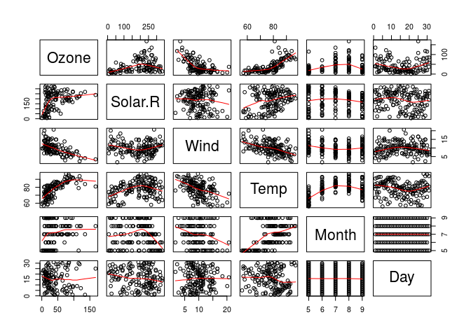

```r
pairs(airquality, panel = panel.smooth)
```

## Linear model fit

We can produce a summary of linear model fit statistics with `lm` and `summary`.

```r
summary(lm(Ozone ~ Wind + Solar.R + Temp, data = airquality))
```

```
##
## Call:
## lm(formula = Ozone ~ Wind + Solar.R + Temp, data = airquality)
##
## Residuals:
##     Min      1Q  Median      3Q     Max
## -40.485 -14.219  -3.551  10.097  95.619
##
## Coefficients:
##              Estimate Std. Error t value Pr(>|t|)
## (Intercept) -64.34208   23.05472  -2.791  0.00623 **
## Wind         -3.33359    0.65441  -5.094 1.52e-06 ***
## Solar.R       0.05982    0.02319   2.580  0.01124 *
## Temp          1.65209    0.25353   6.516 2.42e-09 ***
## ---
## Signif. codes:  0 '***' 0.001 '**' 0.01 '*' 0.05 '.' 0.1 ' ' 1
##
## Residual standard error: 21.18 on 107 degrees of freedom
##   (42 observations deleted due to missingness)
## Multiple R-squared:  0.6059, Adjusted R-squared:  0.5948
## F-statistic: 54.83 on 3 and 107 DF,  p-value: < 2.2e-16
```

## Remove the NA values

To avoid warnings with `qplot` and `ggplot`, we first need to remove the `NA` values with `na.omit`. We will create a new `data.frame` in the process, so that the original dataset will remain unchanged.

```r
df <- na.omit(as.data.frame(airquality))
summary(df)
```

```
##      Ozone          Solar.R           Wind            Temp
##  Min.   :  1.0   Min.   :  7.0   Min.   : 2.30   Min.   :57.00
##  1st Qu.: 18.0   1st Qu.:113.5   1st Qu.: 7.40   1st Qu.:71.00
##  Median : 31.0   Median :207.0   Median : 9.70   Median :79.00
##  Mean   : 42.1   Mean   :184.8   Mean   : 9.94   Mean   :77.79
##  3rd Qu.: 62.0   3rd Qu.:255.5   3rd Qu.:11.50   3rd Qu.:84.50
##  Max.   :168.0   Max.   :334.0   Max.   :20.70   Max.   :97.00
##      Month            Day
##  Min.   :5.000   Min.   : 1.00
##  1st Qu.:6.000   1st Qu.: 9.00
##  Median :7.000   Median :16.00
##  Mean   :7.216   Mean   :15.95
##  3rd Qu.:9.000   3rd Qu.:22.50
##  Max.   :9.000   Max.   :31.00
```

## Plot Ozone versus Temp

Plot `Ozone` versus `Temp` with a linear regression fit using `ggplot` and `method="lm"`.

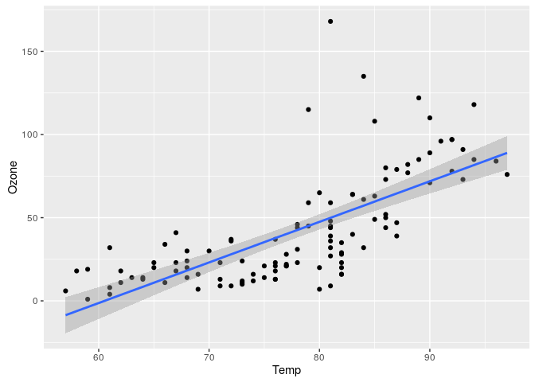

```r
ggplot(df, aes(x = Temp, y = Ozone)) +
  geom_point() + stat_smooth(method = "lm")
```

## Add a Date column

Knowing the data was collected in 1973, we can combine this year with the `Month` and `Day` to get a `Date` column. That will allow us to produce a time series plot.

```r
df$Date <- as.Date(paste("1973", df$Month, df$Day, sep="-"), "%Y-%m-%d")
str(df)
```

```
## 'data.frame':    111 obs. of  7 variables:
##  $ Ozone  : int  41 36 12 18 23 19 8 16 11 14 ...
##  $ Solar.R: int  190 118 149 313 299 99 19 256 290 274 ...
##  $ Wind   : num  7.4 8 12.6 11.5 8.6 13.8 20.1 9.7 9.2 10.9 ...
##  $ Temp   : int  67 72 74 62 65 59 61 69 66 68 ...
##  $ Month  : int  5 5 5 5 5 5 5 5 5 5 ...
##  $ Day    : int  1 2 3 4 7 8 9 12 13 14 ...
##  $ Date   : Date, format: "1973-05-01" "1973-05-02" ...
##  - attr(*, "na.action")=Class 'omit'  Named int [1:42] 5 6 10 11 25 26 27 32 33 34 ...
##   .. ..- attr(*, "names")= chr [1:42] "5" "6" "10" "11" ...
```

## Reshape Temp and Ozone

We will `select` only the `Temp`, `Ozone`, and `Date` variables, then “reshape” the dataset into a “long” format with `melt`.

```r
df <- select(df, Temp, Ozone, Date)
df <- melt(df, id="Date")

str(df)
```

```
## 'data.frame':    222 obs. of  3 variables:
##  $ Date    : Date, format: "1973-05-01" "1973-05-02" ...
##  $ variable: Factor w/ 2 levels "Temp","Ozone": 1 1 1 1 1 1 1 1 1 1 ...
##  $ value   : int  67 72 74 62 65 59 61 69 66 68 ...
```

## Time Series Plot

Now we can plot `Temp` and `Ozone` in a time series, with “loess” curves.

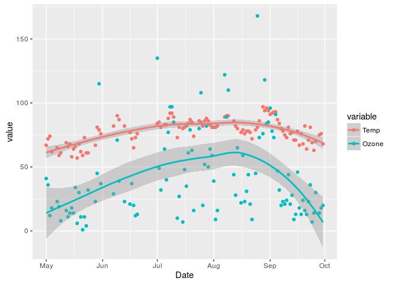

```r
ggplot(df, aes(x=Date, y=value, colour=variable, group=variable)) +
   geom_point(aes(y=value, colour=variable)) + geom_smooth(method="loess")
```